**Comfortable reading and full navigation (recommended)**

> Web report (HTML):  
> https://crgalleguillos.github.io/flight-price-prediction/

> Note: GitHub may not reliably support internal navigation inside `.ipynb` files.  
> The web report is intended as the primary reading version.

# Flight Price Prediction (Economy & Business)

**Author**: Cristián Andrés Galleguillos Vega  
**Objective**: Build and evaluate machine learning models to predict flight prices in **Economy** and **Business** segments.

## Notebook map

1. Context and objective
2. Data and preparation
3. EDA (univariate and bivariate)
4. Feature engineering
5. Modeling and validation
6. Results
7. Conclusions and next steps
8. Credits and technologies

## 1. Context and objective

Flight price estimation is a key task for decision-making in **pricing strategies** and commercial planning.  
In this project, we address **flight price prediction** for two relevant market segments: **Economy** and **Business**.

**Main objective:**  
Train and compare machine learning models capable of predicting the final flight price, quantifying prediction error and evaluating performance stability.

**Business value:**  
This analysis helps identify which variables drive flight prices and supports **dynamic pricing strategies** and market monitoring.

## 2. Data and preparation

**Data sources:**  
Files `business.xlsx` and `economy.xlsx` provided as part of the challenge.

**Structure:**  
Each file contains detailed flight information (origin, destination, airline, duration, stops, etc.) and the target variable `price`.

**Steps performed:**

1. Review of missing values and duplicates
2. Detection and correction of outliers using **IQR capping**
3. Conversion of `duration` into total minutes
4. Encoding of categorical variables (One-Hot Encoding)
5. Train/test split using `random_state=123`

## 3. Exploratory Data Analysis (EDA)

In this stage, we perform an **exploratory data analysis (EDA)** to understand the structure, distributions, and relationships between variables.

EDA allows us to detect outliers, correlations, and differences between the **Economy** and **Business** segments before applying predictive models.

**EDA objectives:**

1. Assess data quality (missing values, duplicates, outliers)
2. Explore numerical variable distributions
3. Analyze relationships between relevant variables and price
4. Identify segment-specific patterns

### 3.1 Initial dataset review

```python
import os
print(os.listdir('../data'))
```

```
['.gitkeep', 'business.xlsx', 'economy.xlsx', 'get_data.py']
```

```python
# MAIN LIBRARIES

# Data analysis and manipulation
import pandas as pd
import numpy as np
import re

# Visualization
import matplotlib.pyplot as plt
import seaborn as sns

# Modeling and evaluation
from sklearn.model_selection import train_test_split
from sklearn.preprocessing import MinMaxScaler
from sklearn.linear_model import Ridge
from sklearn.ensemble import RandomForestRegressor, GradientBoostingRegressor
from sklearn.metrics import mean_absolute_error, mean_squared_error, r2_score

# General configuration
import warnings
warnings.filterwarnings('ignore')
```

```python
# Load data

econ = pd.read_excel('../data/economy.xlsx')
bus  = pd.read_excel('../data/business.xlsx')

# Display basic structure
print("Economy:", econ.shape, "rows x columns")
print("Business:", bus.shape, "rows x columns")

# First rows
display(econ.head(5))
display(bus.head(5))

# Data types
print("\nData types – Economy")
display(econ.dtypes)
```

```
Economy: (206774, 11) rows x columns
Business: (93487, 11) rows x columns
```

|  | date | airline | ch_code | num_code | dep_time | from | time_taken | stop | arr_time | to | price |
| --- | --- | --- | --- | --- | --- | --- | --- | --- | --- | --- | --- |
| 0 | 2022-02-11 | SpiceJet | SG | 8709 | 18:55:00 | Delhi | 02h 10m | non-stop | 21:05:00 | Mumbai | 5953 |
| 1 | 2022-02-11 | SpiceJet | SG | 8157 | 06:20:00 | Delhi | 02h 20m | non-stop | 08:40:00 | Mumbai | 5953 |
| 2 | 2022-02-11 | AirAsia | I5 | 764 | 04:25:00 | Delhi | 02h 10m | non-stop | 06:35:00 | Mumbai | 5956 |
| 3 | 2022-02-11 | Vistara | UK | 995 | 10:20:00 | Delhi | 02h 15m | non-stop | 12:35:00 | Mumbai | 5955 |
| 4 | 2022-02-11 | Vistara | UK | 963 | 08:50:00 | Delhi | 02h 20m | non-stop | 11:10:00 | Mumbai | 5955 |

|  | date | airline | ch_code | num_code | dep_time | from | time_taken | stop | arr_time | to | price |
| --- | --- | --- | --- | --- | --- | --- | --- | --- | --- | --- | --- |
| 0 | 2022-02-11 | Air India | AI | 868 | 18:00:00 | Delhi | 02h 00m | non-stop | 20:00:00 | Mumbai | 25612 |
| 1 | 2022-02-11 | Air India | AI | 624 | 19:00:00 | Delhi | 02h 15m | non-stop | 21:15:00 | Mumbai | 25612 |
| 2 | 2022-02-11 | Air India | AI | 531 | 20:00:00 | Delhi | 24h 45m | 1-stop\n\t\t\t\t\t\t\t\t\t\t\t\t\n\t\t\t\t\t\t... | 20:45:00 | Mumbai | 42220 |
| 3 | 2022-02-11 | Air India | AI | 839 | 21:25:00 | Delhi | 26h 30m | 1-stop\n\t\t\t\t\t\t\t\t\t\t\t\t\n\t\t\t\t\t\t... | 23:55:00 | Mumbai | 44450 |
| 4 | 2022-02-11 | Air India | AI | 544 | 17:15:00 | Delhi | 06h 40m | 1-stop\n\t\t\t\t\t\t\t\t\t\t\t\t\n\t\t\t\t\t\t... | 23:55:00 | Mumbai | 46690 |

```
Data types – Economy
```

```
date          datetime64[ns]
airline               object
ch_code               object
num_code               int64
dep_time              object
from                  object
time_taken            object
stop                  object
arr_time              object
to                    object
price                  int64
dtype: object
```

#### Initial observations

- Both datasets (Economy and Business) share the same structure:  
  `date`, `airline`, `ch_code`, `num_code`, `dep_time`, `from`, `time_taken`, `stop`, `arr_time`, `to`, `price`
- Columns such as `date`, `dep_time`, `arr_time`, and `time_taken` are stored as text or mixed formats and must be converted into **datetime** or **numeric** values.
- Variables `from` and `to` represent origin and destination cities; they will be renamed to `origin` and `destination` to avoid conflicts with Python reserved words.
- `price` is the **target variable**, stored as an integer (`int64`), confirming this is a **supervised regression problem**.
- `num_code` is a flight identifier and likely provides no predictive value.

#### Data quality: missing values and duplicates

```python
# Percentage of missing values
nulls_econ = econ.isna().mean() * 100
nulls_bus = bus.isna().mean() * 100

print("Missing values in Economy:")
display(nulls_econ[nulls_econ > 0].sort_values(ascending=False))

print("\nMissing values in Business:")
display(nulls_bus[nulls_bus > 0].sort_values(ascending=False))

# Duplicates
dup_econ = econ.duplicated().sum()
dup_bus = bus.duplicated().sum()

print(f"\nDuplicates – Economy: {dup_econ} | Business: {dup_bus}")
```

```
Missing values in Economy:
```

```
Series([], dtype: float64)
```

```
Missing values in Business:
```

```
Series([], dtype: float64)
```

```
Duplicates – Economy: 2 | Business: 0
```

```python
# Remove duplicates from the Economy dataset
econ = econ.drop_duplicates().reset_index(drop=True)
print(f"Economy after removing duplicates: {econ.shape}")
```

```
Economy after removing duplicates: (206772, 11)
```

#### Note

**Results:**

- No missing values were found in either **Economy** or **Business** datasets.
- **2 duplicate records** were detected in the Economy dataset and **0 duplicates** in Business.
- The final Economy dataset was reduced from **206,774 to 206,772 rows**, while Business remained at **93,487 rows**.

**Action taken:**

- Duplicate records in Economy were removed to preserve data integrity.

**Conclusion:**

- The datasets show **excellent initial quality**, with no missing values or major inconsistencies.
- This allows us to proceed directly to exploratory analysis and feature transformation without the need for imputation.

#### 3.2 Distribution of numerical variables

We analyze the distribution of key numerical variables:

- **`price`**, to assess dispersion and skewness across segments
- **`duration_mins`**, to understand the distribution of flight durations in minutes

This helps identify **biases, long tails, and extreme values** prior to outlier treatment.

#### Data preparation and cleaning

```python
# 1) Ensure `price` is numeric (handles comma formats like "1,14,434", spaces, or other symbols)
def clean_price(series: pd.Series) -> pd.Series:
    s = series.astype(str).str.strip()
    # Remove all non-numeric characters (supports "Indian-style" comma formats)
    s = s.str.replace(r'[^0-9]', '', regex=True)
    # Empty strings -> NA; use Int64 to tolerate NA during cleaning
    s = s.replace('', pd.NA).astype('Int64')
    return s

econ['price'] = clean_price(econ['price'])
bus['price']  = clean_price(bus['price'])

# Remove rows with NA price
before_e, before_b = len(econ), len(bus)
econ = econ.dropna(subset=['price']).reset_index(drop=True)
bus  = bus.dropna(subset=['price']).reset_index(drop=True)
print(f"[Economy] rows: {before_e} -> {len(econ)} (after normalizing 'price')")
print(f"[Business] rows: {before_b} -> {len(bus)} (after normalizing 'price')")

# Final cast to int (no NA values remaining)
econ['price'] = econ['price'].astype(int)
bus['price']  = bus['price'].astype(int)

# 2) Convert `time_taken` -> total minutes in `duration_mins`
def to_minutes(duration_str):
    if isinstance(duration_str, str):
        hours = re.findall(r'(\d+)h', duration_str)
        mins  = re.findall(r'(\d+)m', duration_str)
        h = int(hours[0]) if hours else 0
        m = int(mins[0])  if mins  else 0
        return h * 60 + m
    return pd.NA

econ['duration_mins'] = econ['time_taken'].apply(to_minutes).astype('Int64')
bus['duration_mins']  = bus['time_taken'].apply(to_minutes).astype('Int64')

print("Types (price, duration_mins) →",
      econ['price'].dtype, econ['duration_mins'].dtype,
      "|", bus['price'].dtype, bus['duration_mins'].dtype)
```

```
[Economy] rows: 206772 -> 206772 (after normalizing 'price')
[Business] rows: 93487 -> 93487 (after normalizing 'price')
Types (price, duration_mins) → int32 Int64 | int32 Int64
```

#### Price histograms by segment

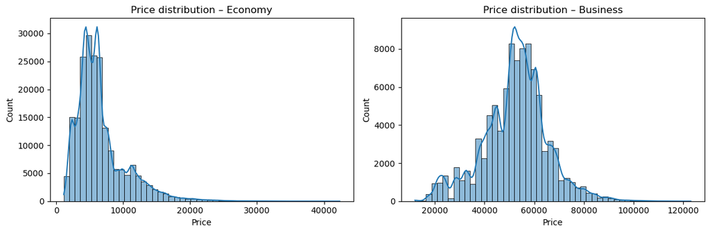

```python
fig, axes = plt.subplots(1, 2, figsize=(12, 4))

sns.histplot(econ['price'].dropna(), bins=50, kde=True, ax=axes[0])
axes[0].set_title('Price distribution – Economy')
axes[0].set_xlabel('Price')

sns.histplot(bus['price'].dropna(), bins=50, kde=True, ax=axes[1])
axes[1].set_title('Price distribution – Business')
axes[1].set_xlabel('Price')

plt.tight_layout()
plt.show()
```

#### Duration_mins histograms by segment

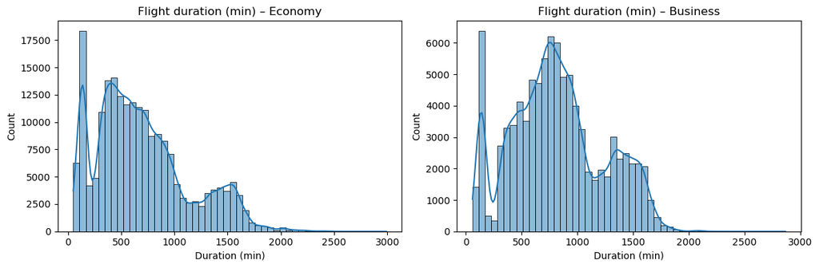

```python
fig, axes = plt.subplots(1, 2, figsize=(12, 4))

sns.histplot(econ['duration_mins'].dropna(), bins=50, kde=True, ax=axes[0])
axes[0].set_title('Flight duration (min) – Economy')
axes[0].set_xlabel('Duration (min)')

sns.histplot(bus['duration_mins'].dropna(), bins=50, kde=True, ax=axes[1])
axes[1].set_title('Flight duration (min) – Business')
axes[1].set_xlabel('Duration (min)')

plt.tight_layout()
plt.show()
```

#### Boxplots for visual outlier detection

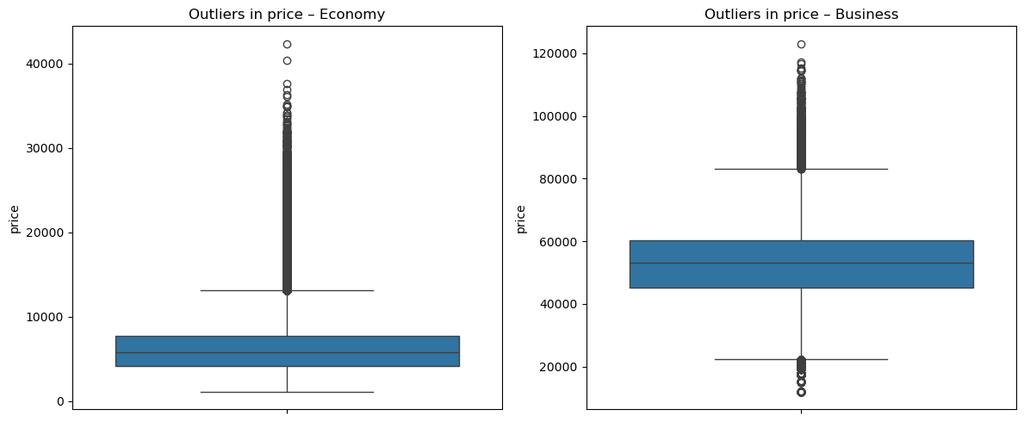

```python
fig, axes = plt.subplots(1, 2, figsize=(12, 5))

sns.boxplot(y=econ['price'].dropna(), ax=axes[0])
axes[0].set_title('Outliers in price – Economy')

sns.boxplot(y=bus['price'].dropna(), ax=axes[1])
axes[1].set_title('Outliers in price – Business')

plt.tight_layout()
plt.show()
```

#### **Observations from numerical analysis**

**Price distribution**

- In the Economy segment, prices are mainly concentrated between 3,000 and 10,000 units, with a long right tail indicating the presence of significantly more expensive flights.
- Several local peaks are observed, likely associated with specific airlines or route types.
- In the Business segment, the distribution is wider and centered around 50,000–60,000 units.
- It also exhibits positive skewness with much greater dispersion, reflecting heterogeneous pricing based on service level or flight class.
- Both histograms confirm that `price` does not follow a normal distribution, making scaling or outlier capping necessary before modeling.

**Flight duration (`duration_mins`)**

- In both segments, most flights fall between 100 and 2,000 minutes (approximately 1.5 to 33 hours).
- Long right tails indicate routes with multiple stops or anomalous records, especially in Economy.

**Boxplots**

- Economy prices cluster below 10,000 units, with many high outliers above 30,000.
- Business prices show a median around 55,000 units, with extreme values reaching up to 120,000.

**Conclusion** Both `price` and `duration_mins` show skewed distributions and the presence of outliers.  
This is common in flight data and does not indicate data errors, but it does require controlled statistical treatment.

In the next step, IQR capping (winsorization) will be applied to mitigate the impact of extreme values without removing observations.

### 3.3 Outlier treatment (IQR capping)

#### Objective

The outliers detected in `price` and `duration_mins` may negatively affect the performance of Machine Learning models, especially in regression tasks.  
We apply the **Interquartile Range (IQR)** method to limit extreme values within a statistically reasonable range, without removing observations.

```python
# IQR-based winsorization function

def iqr_capping(df, column, multiplier=1.5):
    """
    Applies IQR-based winsorization.
    Caps values below (Q1 - 1.5*IQR)
    and above (Q3 + 1.5*IQR).
    Returns the modified DataFrame and the limits.
    """
    Q1 = df[column].quantile(0.25)
    Q3 = df[column].quantile(0.75)
    IQR = Q3 - Q1
    lower = Q1 - multiplier * IQR
    upper = Q3 + multiplier * IQR
    capped = df[column].clip(lower, upper)
    print(f"{column}: IQR range [{lower:.2f}, {upper:.2f}]")
    print(f"Capped values: {(df[column] != capped).sum()}")
    df[column] = capped
    return df, lower, upper

# Apply to both variables in both segments
econ, l1, u1 = iqr_capping(econ, 'price')
bus,  l2, u2 = iqr_capping(bus,  'price')
econ, l3, u3 = iqr_capping(econ, 'duration_mins')
bus,  l4, u4 = iqr_capping(bus,  'duration_mins')
```

```
price: IQR range [-1186.50, 13105.50]
Capped values: 13750
price: IQR range [22368.50, 83212.50]
Capped values: 3650
duration_mins: IQR range [-435.00, 1725.00]
Capped values: 2652
duration_mins: IQR range [-280.00, 1880.00]
Capped values: 90
```

### Outlier treatment (IQR capping)

#### Results

- **Economy – `price`:** IQR range applied **[-1,186.5, 13,105.5]**, therefore **13,750 values capped** (≈ 6.6%).
- **Business – `price`:** IQR range applied **[22,368.5, 83,212.5]**, therefore **3,650 values capped** (≈ 3.9%).
- **Economy – `duration_mins`:** IQR range applied **[-435, 1,725]** min, therefore **2,652 records adjusted**.
- **Business – `duration_mins`:** IQR range applied **[-280, 1,880]** min, therefore **90 records adjusted**.

> Note: negative lower bounds are corrected using `clip()` and truncated to the actual minimum (> 0).

#### Visualization before and after

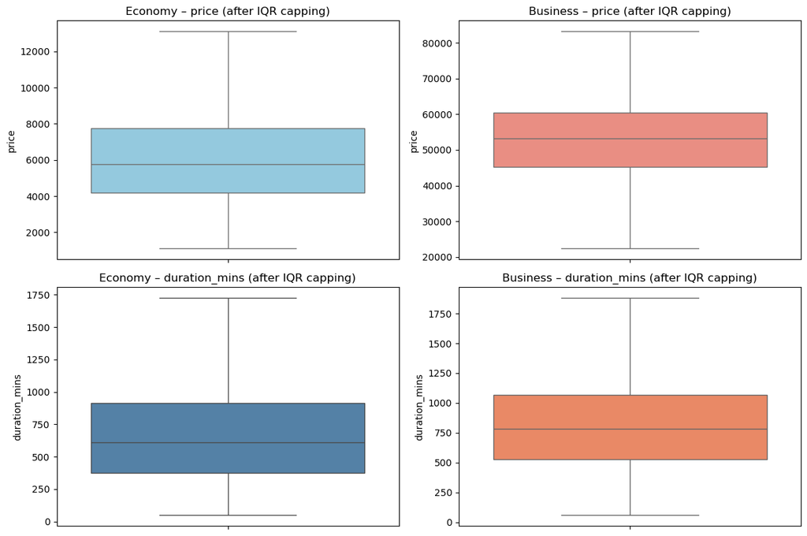

```python
fig, axes = plt.subplots(2, 2, figsize=(12, 8))

sns.boxplot(y=econ['price'], ax=axes[0,0], color='skyblue')
axes[0,0].set_title('Economy – price (after IQR capping)')

sns.boxplot(y=bus['price'], ax=axes[0,1], color='salmon')
axes[0,1].set_title('Business – price (after IQR capping)')

sns.boxplot(y=econ['duration_mins'], ax=axes[1,0], color='steelblue')
axes[1,0].set_title('Economy – duration_mins (after IQR capping)')

sns.boxplot(y=bus['duration_mins'], ax=axes[1,1], color='coral')
axes[1,1].set_title('Business – duration_mins (after IQR capping)')

plt.tight_layout()
plt.show()
```

#### Boxplot interpretation

- After capping, the distributions become **more compact and symmetric**, with no visible outliers.
- **Economy (`price`)** preserves a median around **~6,000**, indicating that adjustments mainly affected marginal values.
- **Business (`price`)** maintains a median around **~55,000**, with controlled dispersion after removing extreme values (> 100,000).
- **`duration_mins`** is mainly stabilized between **~300 and 1,500 minutes**, consistent with domestic and international routes.

#### Conclusion

- **IQR capping** reduced the impact of extreme values **without removing observations**, preserving dataset integrity.
- Variables are now **more robust for modeling** (lower sensitivity to extremes in regression/boosting).
- `price` and `duration_mins` are **ready for bivariate analysis** and the modeling stage.

### 3.4 Bivariate analysis

#### Objective

Explore the relationships between `price` (target variable) and other dataset variables to identify patterns and factors influencing flight prices.

The following are analyzed:

- Numerical relationships (`duration_mins` vs `price`) using correlation and scatter plots.
- Categorical relationships (`stop`, `airline`, `from`, `to`) using comparative boxplots.

#### Correlation between numerical variables

```python
# Calculate correlations for numerical variables
corr_econ = econ[['price', 'duration_mins']].corr()
corr_bus  = bus[['price', 'duration_mins']].corr()

print("Correlation – Economy:")
display(corr_econ)

print("Correlation – Business:")
display(corr_bus)
```

```
Correlation – Economy:
```

|  | price | duration_mins |
| --- | --- | --- |
| price | 1.000000 | 0.313434 |
| duration_mins | 0.313434 | 1.000000 |

```
Correlation – Business:
```

|  | price | duration_mins |
| --- | --- | --- |
| price | 1.000000 | 0.243108 |
| duration_mins | 0.243108 | 1.000000 |

### Correlation between numerical variables

| Segment | Correlation `price` – `duration_mins` |
| --- | --- |
| Economy | **0.31** |
| Business | **0.24** |

#### Observations

- In both segments, a **positive correlation** is observed: longer flights tend to be more expensive.
- The relationship strength is **moderate in Economy (0.31)** and **weaker in Business (0.24)**.
- This suggests that in *Business*, price also depends on other factors (service level, airline, class, schedules), while in *Economy*, flight duration carries slightly more weight.

#### Visualization: price vs duration_mins

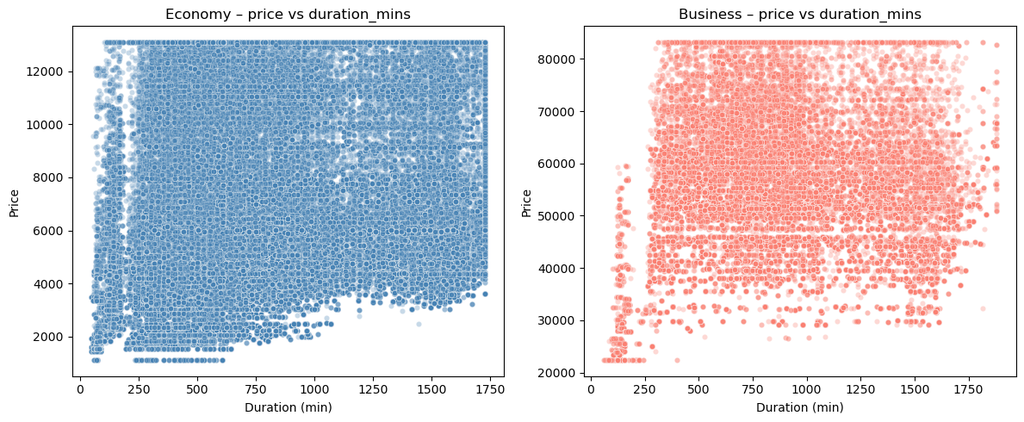

```python
fig, axes = plt.subplots(1, 2, figsize=(12, 5))

sns.scatterplot(data=econ, x='duration_mins', y='price', alpha=0.3, s=20, ax=axes[0], color='steelblue')
axes[0].set_title('Economy – price vs duration_mins')
axes[0].set_xlabel('Duration (min)')
axes[0].set_ylabel('Price')

sns.scatterplot(data=bus, x='duration_mins', y='price', alpha=0.3, s=20, ax=axes[1], color='salmon')
axes[1].set_title('Business – price vs duration_mins')
axes[1].set_xlabel('Duration (min)')
axes[1].set_ylabel('Price')

plt.tight_layout()
plt.show()
```

#### Observations

- In **Economy**, a **slightly upward trend** is observed: flights longer than 1,000 minutes tend to concentrate higher prices, although dispersion increases.
- In **Business**, the point cloud is more **scattered**, confirming that price does not depend solely on duration, but also on airline and flight type.
- Both plots show a **non-linear relationship**, suggesting that logarithmic or polynomial transformations could be useful in predictive models.

#### Cleaning the `stop` variable

```python
def normalize_stop(s):
    if pd.isna(s):
        return pd.NA
    t = str(s).lower()
    t = re.sub(r'\s+', ' ', t).strip()
    t = t.replace('non stop', 'non-stop').replace('non-stop', '0-stop')
    m = re.search(r'(\d+)\s*[- ]*\s*stop', t)
    if '0-stop' in t:
        n = 0
    elif m:
        n = int(m.group(1))
    else:
        mplus = re.search(r'(\d+)\s*\+\s*stop', t)
        if mplus:
            n = int(mplus.group(1)) + 1
        else:
            return pd.NA
    if n == 0:
        return 'non-stop'
    elif n == 1:
        return '1-stop'
    else:
        return '2+-stops'

econ['stop_clean'] = econ['stop'].apply(normalize_stop)
bus['stop_clean']  = bus['stop'].apply(normalize_stop)

print(econ['stop_clean'].value_counts())
print(bus['stop_clean'].value_counts())
```

```
stop_clean
1-stop      166625
non-stop     27942
Name: count, dtype: int64
stop_clean
1-stop      84302
non-stop     8102
Name: count, dtype: int64
```

#### Price by number of stops (clean boxplots)

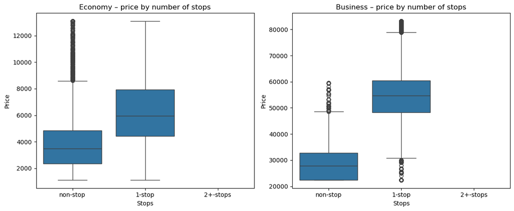

```python
order = ['non-stop', '1-stop', '2+-stops']

fig, axes = plt.subplots(1, 2, figsize=(12, 5))

sns.boxplot(
    x='stop_clean', y='price',
    data=econ.dropna(subset=['stop_clean']),
    order=order, ax=axes[0]
)
axes[0].set_title('Economy – price by number of stops')
axes[0].set_xlabel('Stops')
axes[0].set_ylabel('Price')

sns.boxplot(
    x='stop_clean', y='price',
    data=bus.dropna(subset=['stop_clean']),
    order=order, ax=axes[1]
)

axes[1].set_title('Business – price by number of stops')
axes[1].set_xlabel('Stops')
axes[1].set_ylabel('Price')

plt.tight_layout()
plt.show()
```

#### Observation: Price by number of stops (`stop_clean`)

[output not shown]

#### Average price by airline

```python
# Top 10 airlines by average price (segment-wise)
mean_price_econ = (
    econ.groupby('airline', dropna=False)['price']
        .mean()
        .sort_values(ascending=False)
        .head(10)
)
mean_price_bus = (
    bus.groupby('airline', dropna=False)['price']
       .mean()
       .sort_values(ascending=False)
       .head(10)
)

# Comprobación
display(mean_price_econ.to_frame('Average price – Economy'))
display(mean_price_bus.to_frame('Average price – Business'))
```

| airline | Average price – Economy |
| --- | --- |
| Vistara | 7484.399829 |
| Air India | 7001.725559 |
| SpiceJet | 6046.644601 |
| GO FIRST | 5587.036027 |
| Indigo | 5206.398098 |
| StarAir | 4860.909836 |
| AirAsia | 4007.103305 |
| Trujet | 3244.634146 |

| airline | Average price – Business |
| --- | --- |
| Vistara | 55373.605324 |
| Air India | 47195.887622 |

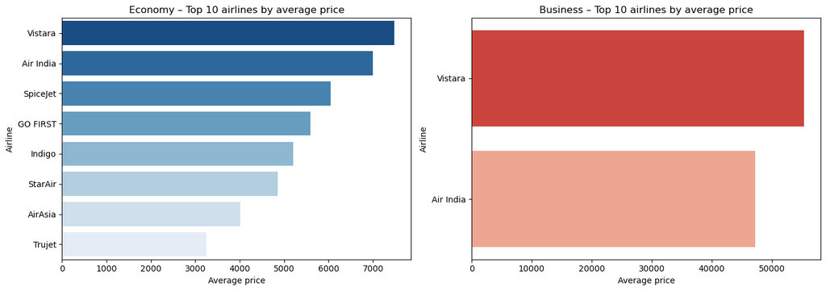

```python
fig, axes = plt.subplots(1, 2, figsize=(14, 5))

sns.barplot(
    x=mean_price_econ.values,
    y=mean_price_econ.index,
    hue=mean_price_econ.index,
    palette='Blues_r',
    legend=False,
    ax=axes[0]
)
axes[0].set_title('Economy – Top 10 airlines by average price')
axes[0].set_xlabel('Average price')
axes[0].set_ylabel('Airline')

sns.barplot(
    x=mean_price_bus.values,
    y=mean_price_bus.index,
    hue=mean_price_bus.index,
    palette='Reds_r',
    legend=False,
    ax=axes[1]
)
axes[1].set_title('Business – Top 10 airlines by average price')
axes[1].set_xlabel('Average price')
axes[1].set_ylabel('Airline')

plt.tight_layout()
plt.show()
```

#### Observations

- In **Economy**, airlines such as **Vistara**, **Air India**, and **SpiceJet** stand out with higher average prices.
- In **Business**, the same airlines lead the ranking, but with much larger differences in average price.
- Low-cost airlines (e.g., *Trujet*, *AirAsia*) show significantly lower prices, reinforcing their market positioning.
- This result suggests that the `airline` variable could be a **relevant predictor** in machine learning models.

### Overall EDA conclusion

The exploratory analysis made it possible to understand the structure, consistency, and most relevant relationships within flight data for the **Economy** and **Business** segments.

**Conclusion:**  
The EDA confirms that the data are **clean, well-structured, and exhibit interpretable relationships** among key variables.  
Clear differences exist between segments and airlines, as well as pricing patterns associated with flight duration and number of stops.

## 4. Feature engineering

### Objective

Optimize the representation of variables, generate relevant new features, and prepare the datasets for predictive modeling.  
The goal is to improve the models’ ability to capture patterns in the data without introducing redundancy or multicollinearity.

### 4.1 Data preprocessing

#### Objective

Standardize and prepare input data for predictive modeling, ensuring column consistency, clean text fields, and the creation of time-based variables that add value to the model.

The purpose is to ensure that variables are ready to be interpreted by Machine Learning algorithms by removing sources of noise or redundancy and improving the quality of feature representations.

### Cleaning and transforming categorical variables

**Main tasks:**

1. **Column renaming:**  
   Reserved or ambiguous names are replaced (`from → origin`, `to → destination`) to avoid conflicts with keywords and improve dataset readability.
2. **Removing irrelevant columns:**  
   Identifier fields (`ch_code`, `num_code`) are removed because they add no predictive value and may introduce noise.
3. **Category normalization:**  
   The `stop` column is cleaned from residual characters (line breaks, tabs, extra spaces) and standardized into a new variable `stop_clean`.  
   This enables correct differentiation between direct flights (`non-stop`), one-stop flights (`1-stop`), and multi-stop flights (`2+-stops`).
4. **Time feature extraction:**  
   From `date`, three attributes are derived:
   - `month`: captures seasonality.
   - `day`: reflects potential day-of-month patterns.
   - `weekday`: helps identify different behaviors between weekdays and weekends.
5. **Deep text cleaning:**  
   Special characters and unnecessary spaces are removed across all text columns, standardizing categorical values for correct downstream encoding.
6. **Removing raw time columns:**  
   Original time columns (`date`, `dep_time`, `arr_time`, `time_taken`) are removed since their relevant components have already been extracted and transformed into modeling-ready features.

```python
# Clean copies
econ_clean = econ.copy()
bus_clean  = bus.copy()

# Rename columns
econ_clean = econ_clean.rename(columns={'from': 'origin', 'to': 'destination'})
bus_clean  = bus_clean.rename(columns={'from': 'origin', 'to': 'destination'})

# Drop irrelevant identifier columns
econ_clean = econ_clean.drop(columns=['ch_code', 'num_code'])
bus_clean  = bus_clean.drop(columns=['ch_code', 'num_code'])

# Normalize stops (preserve all possible categories)
econ_clean['stop_clean'] = econ_clean['stop'].astype(str).str.replace(r'[\n\t]+', ' ', regex=True).str.strip()
bus_clean['stop_clean']  = bus_clean['stop'].astype(str).str.replace(r'[\n\t]+', ' ', regex=True).str.strip()

# Extract month, day, and weekday from the date
econ_clean['month'] = pd.to_datetime(econ_clean['date'], errors='coerce').dt.month
econ_clean['day'] = pd.to_datetime(econ_clean['date'], errors='coerce').dt.day
econ_clean['weekday'] = pd.to_datetime(econ_clean['date'], errors='coerce').dt.weekday

bus_clean['month'] = pd.to_datetime(bus_clean['date'], errors='coerce').dt.month
bus_clean['day'] = pd.to_datetime(bus_clean['date'], errors='coerce').dt.day
bus_clean['weekday'] = pd.to_datetime(bus_clean['date'], errors='coerce').dt.weekday

# Remove raw date/time columns (no longer needed in X)
cols_time = ['date', 'dep_time', 'arr_time', 'time_taken']
econ_clean = econ_clean.drop(columns=[c for c in cols_time if c in econ_clean.columns])
bus_clean  = bus_clean.drop(columns=[c for c in cols_time if c in bus_clean.columns])

# Deep string cleaning: remove line breaks, tabs, and extra spaces
def limpiar_texto(col):
    if col.dtype == 'object':
        return col.astype(str).str.replace(r'[\n\t]+', ' ', regex=True).str.strip()
    return col

econ_clean = econ_clean.apply(limpiar_texto)
bus_clean  = bus_clean.apply(limpiar_texto)
```

### 4.2 Encoding categorical variables

#### Objective

Transform categorical variables into numerical representations without losing information or interpretability, allowing algorithms to process them correctly.

#### Applied strategy

**One-Hot Encoding (OHE)** is applied to the main categorical variables:

- `airline` → Represents the operating airline.
- `origin` and `destination` → Capture route and airport effects on prices.
- `stop_clean` → Indicates the number of stops (a key factor in the final fare).

OHE creates new binary columns for each category (e.g., `airline_Indigo`, `destination_Mumbai`, etc.), assigning values `1` or `0` accordingly.  
This way, numerical models can correctly interpret these variables **without imposing an artificial order**, which would occur with Label Encoding.

Numerical variables (`duration_mins`, `month`, `day`, `weekday`) are kept unchanged at this stage, as they will be scaled later.

```python
cat_vars_e = [c for c in ['airline','origin','destination','stop_clean'] if c in econ_clean.columns]
cat_vars_b = [c for c in ['airline','origin','destination','stop_clean'] if c in bus_clean.columns]

num_vars_e = [c for c in ['duration_mins','month','day','weekday'] if c in econ_clean.columns]
num_vars_b = [c for c in ['duration_mins','month','day','weekday'] if c in bus_clean.columns]

# OHE without touching numeric variables
X_econ = pd.concat([econ_clean[num_vars_e], pd.get_dummies(econ_clean[cat_vars_e], drop_first=True)], axis=1)
X_bus  = pd.concat([bus_clean[num_vars_b],  pd.get_dummies(bus_clean[cat_vars_b],  drop_first=True)], axis=1)

y_econ = econ_clean['price'].astype(int)
y_bus  = bus_clean['price'].astype(int)

print("Economy – X:", X_econ.shape, "| y:", y_econ.shape)
print("Business – X:", X_bus.shape,  "| y:", y_bus.shape)
```

```
Economy – X: (206772, 57) | y: (206772,)
Business – X: (93487, 39) | y: (93487,)
```

#### Note

The increase in the number of columns reflects the creation of binary variables from the original categories.  
This is expected: the Economy dataset, with more airlines and routes, produces 57 columns after encoding, while Business, with fewer combinations, produces 39.

### 4.3 Scaling numerical variables

#### Objective

Normalize numerical variables so they operate within the same magnitude range and **no single feature dominates the learning process**.

Variables with different units (e.g., duration in minutes vs. month index) can negatively affect training for models based on distances or gradients, since larger values tend to exert more influence.

#### Applied method

We use **MinMaxScaler** from `sklearn`, which transforms each variable to the `[0, 1]` range, preserving the original distribution shape and facilitating algorithm convergence.

Unlike earlier versions, scaling is **applied only to continuous numerical variables**, avoiding any alteration to one-hot encoded categorical variables (dummies), which are already binary.

Scaled variables:

```
plaintext
['duration_mins', 'month', 'day', 'weekday']
```

```python
scaler_e = MinMaxScaler()
scaler_b = MinMaxScaler()

X_econ_scaled = X_econ.copy()
X_bus_scaled  = X_bus.copy()

X_econ_scaled[num_vars_e] = scaler_e.fit_transform(X_econ_scaled[num_vars_e])
X_bus_scaled[num_vars_b]  = scaler_b.fit_transform(X_bus_scaled[num_vars_b])

print("Scaling applied only to:", num_vars_e)
```

```
Scaling applied only to: ['duration_mins', 'month', 'day', 'weekday']
```

#### Note

Only numerical variables have been rescaled, while dummy variables remain unchanged.

This ensures that the model:

- Does not distort relationships between categories.
- Learns magnitude-driven patterns in a balanced way.
- Becomes more stable and efficient during parameter optimization.

In practical terms, this step improves training robustness and prevents biases caused by scale differences across heterogeneous variables.

### 4.4 Train/test split

#### Objective

Evaluate the model’s generalization capability by splitting the dataset into two subsets:

- **Training (80%)**: used to fit model parameters.
- **Test (20%)**: reserved to measure performance on unseen data.

This split helps detect overfitting and ensures the model can predict correctly in new scenarios.

#### Implementation

We use `train_test_split` from `sklearn.model_selection`, ensuring reproducibility with `random_state=123`.

```python
X_train_e, X_test_e, y_train_e, y_test_e = train_test_split(
    X_econ_scaled, y_econ, test_size=0.2, random_state=123
)
X_train_b, X_test_b, y_train_b, y_test_b = train_test_split(
    X_bus_scaled, y_bus, test_size=0.2, random_state=123
)

print("Economy – Train/Test:", X_train_e.shape, X_test_e.shape)
print("Business – Train/Test:", X_train_b.shape, X_test_b.shape)
```

```
Economy – Train/Test: (165417, 57) (41355, 57)
Business – Train/Test: (74789, 39) (18698, 39)
```

#### Note

Each segment retains an appropriate ratio for supervised learning, with enough examples for models to capture general patterns and validate performance under realistic conditions.

In addition, the final feature dimensions (57 columns for Economy and 39 for Business) confirm that encoding and scaling were performed correctly, ensuring consistency across train and test matrices.

### 4.5 Removing residual columns (object / datetime)

#### Objective

Verify that no incompatible data types (`object` or `datetime`) remain in the training and test sets before modeling.

Many Machine Learning algorithms—such as **Ridge**, **Random Forest**, and **Gradient Boosting**—only accept numerical inputs.  
Therefore, this step ensures the entire feature matrix is in the proper format for training.

#### Implementation

The code checks both segments (Economy and Business) and removes any residual columns with `object` type:

```python
### 4.5 Removing residual columns (object / datetime)

# Remove any residual object-type columns (e.g., 'stop')
cols_obj = X_train_e.select_dtypes(include='object').columns
if len(cols_obj) > 0:
    print("Text columns removed (Economy):", list(cols_obj))
    X_train_e = X_train_e.drop(columns=cols_obj)
    X_test_e  = X_test_e.drop(columns=cols_obj)

cols_obj_b = X_train_b.select_dtypes(include='object').columns
if len(cols_obj_b) > 0:
    print("Text columns removed (Business):", list(cols_obj_b))
    X_train_b = X_train_b.drop(columns=cols_obj_b)
    X_test_b  = X_test_b.drop(columns=cols_obj_b)
```

#### Note

In this case, no residual columns were detected, confirming that preprocessing was complete and consistent.  
This means all predictors (X_train and X_test) are numeric and ready to be used by the models in the next stage.

### Overall conclusion of Feature Engineering

After the transformation and preparation process, the **Economy** and **Business** datasets are fully ready for supervised modeling.

#### Summary of steps performed:

- Columns were **renamed** (`from` → `origin`, `to` → `destination`) to avoid conflicts with reserved words and improve dataset semantics.
- **Irrelevant variables** (`ch_code`, `num_code`) were removed, and categorical text fields were cleaned (line breaks, tabs, extra spaces).
- The `stop_clean` column was **normalized**, preserving all valid categories (non-stop, 1-stop, 2+-stops) without collapsing information.
- From the date (`date`), new **time-based features** were extracted:
  - `month` (flight month)
  - `day` (day of month)
  - `weekday` (day of week)  
    These features capture potential seasonal and temporal patterns.
- **One-Hot Encoding** was applied to categorical variables (`airline`, `origin`, `destination`, `stop_clean`) to convert them into binary indicators.
- **Only numerical variables** (`duration_mins`, `month`, `day`, `weekday`) were scaled using **Min–Max Scaling**, keeping dummy variables unchanged.
- Data were split into **training (80%) and test (20%)** sets, ensuring reproducibility (`random_state=123`).
- A final check confirmed that no residual `object` or `datetime` columns remained.

#### Results:

- **Economy:** 206,772 records → 57 final features.
- **Business:** 93,487 records → 39 final features.
- Splits:
  - *Economy:* 165,417 train / 41,355 test
  - *Business:* 74,789 train / 18,698 test

#### Conclusion

Feature engineering produced datasets that are **numerically consistent, enriched, and modeling-ready**, combining clean transformations, useful time features, and efficient encoding.

These decisions increase **predictive capacity and model stability**, improve interpretability, and ensure a coherent data pipeline from extraction through the machine learning stage.

## 5. Modeling and Validation

### Objective

Train, evaluate, and compare different **supervised Machine Learning** models with the goal of **predicting flight prices** in the *Economy* and *Business* segments.

The objective is to determine which algorithm achieves the best **balance between accuracy, generalization capability, and computational efficiency**, considering the tabular and heterogeneous nature of the dataset.

The results allow us to identify **which model performs best for each market segment**, with potential applications in real-world contexts such as:

- **dynamic pricing systems (pricing engines)**,
- **route and schedule optimization**, or
- **profitability analysis tools** by airline or destination.

### 5.1 Selected models

Three representative algorithms were selected, each reflecting a different supervised learning approach.  
The goal is to evaluate both linear models and more complex ensembles, with different ways of handling non-linearity and overfitting.

| **Model** | **Type** | **Main characteristics** |
| --- | --- | --- |
| **Ridge Regression** | Linear | Introduces L2 regularization to control overfitting. Used as a **baseline model** due to its simplicity and interpretability. |
| **Random Forest Regressor** | Ensemble (bagging) | Combines multiple decision trees trained on random subsets. Captures **non-linear relationships** and handles variance effectively. |
| **Gradient Boosting Regressor** | Ensemble (boosting) | Trains trees sequentially, correcting residual errors from previous models. Often achieves **high accuracy** on tabular data at the cost of higher computational complexity. |

#### Interpretation

This selection balances interpretability and predictive power:

- Ridge helps understand the contribution of each variable to price.
- Random Forest provides robustness and stability against noise and outliers.
- Gradient Boosting aims to maximize final accuracy by leveraging non-linear relationships and feature interactions.

Together, these models allow us to evaluate **how linear and ensemble techniques respond to the same data**, providing a solid foundation for comparative analysis.

### 5.2 Model training and evaluation

#### Objective

Train and evaluate each model on both segments (*Economy* and *Business*) using three key metrics that capture both accuracy and generalization capability:

- **MAE (Mean Absolute Error):** measures the average absolute error. Easy to interpret, as it is expressed in the same units as the target variable (price).
- **RMSE (Root Mean Squared Error):** penalizes large errors more heavily, making it sensitive to highly deviated predictions.
- **R² (Coefficient of determination):** indicates the proportion of price variability explained by the model (values closer to 1 imply better fit).

#### Implementation

The following function generalizes the training, prediction, and metric computation process for any supervised regression model:

```python
def evaluar_modelo(nombre, modelo, X_train, y_train, X_test, y_test):
    modelo.fit(X_train, y_train)
    y_pred = modelo.predict(X_test)

    mae = mean_absolute_error(y_test, y_pred)
    rmse = np.sqrt(mean_squared_error(y_test, y_pred))
    r2 = r2_score(y_test, y_pred)

    resultados = pd.DataFrame({
        "Modelo": [nombre],
        "MAE": [mae],
        "RMSE": [rmse],
        "R²": [r2]
    })

    return resultados
```

#### Implementation note

This function standardizes the evaluation of the three selected models, ensuring consistent comparisons.

Additionally:

- A low MAE indicates that average predictions closely match true values.
- An RMSE significantly larger than MAE may reveal outliers or isolated large errors.
- An R² close to 1 indicates that the model captures most of the variability in price, serving as a strong global performance indicator.

```python
# Models
ridge = Ridge(alpha=1.0)
rf = RandomForestRegressor(n_estimators=200, random_state=123)
gb = GradientBoostingRegressor(n_estimators=300, learning_rate=0.05, random_state=123)
```

```python
# Economy evaluation
resultados_econ = pd.concat([
    evaluar_modelo("Ridge", ridge, X_train_e, y_train_e, X_test_e, y_test_e),
    evaluar_modelo("Random Forest", rf, X_train_e, y_train_e, X_test_e, y_test_e),
    evaluar_modelo("Gradient Boosting", gb, X_train_e, y_train_e, X_test_e, y_test_e)
], ignore_index=True)
```

```python
# Business evaluation
resultados_bus = pd.concat([
    evaluar_modelo("Ridge", ridge, X_train_b, y_train_b, X_test_b, y_test_b),
    evaluar_modelo("Random Forest", rf, X_train_b, y_train_b, X_test_b, y_test_b),
    evaluar_modelo("Gradient Boosting", gb, X_train_b, y_train_b, X_test_b, y_test_b)
], ignore_index=True)

display(resultados_econ)
display(resultados_bus)
```

|  | Modelo | MAE | RMSE | R² |
| --- | --- | --- | --- | --- |
| 0 | Ridge | 1467.493852 | 1920.838018 | 0.615342 |
| 1 | Random Forest | 585.683525 | 1110.255849 | 0.871489 |
| 2 | Gradient Boosting | 1135.728870 | 1556.337215 | 0.747477 |

|  | Modelo | MAE | RMSE | R² |
| --- | --- | --- | --- | --- |
| 0 | Ridge | 6690.613904 | 8614.589314 | 0.534524 |
| 1 | Random Forest | 2549.234778 | 4782.555600 | 0.856534 |
| 2 | Gradient Boosting | 5644.624314 | 7436.028760 | 0.653175 |

### Observation: model evaluation

Below are the results obtained by the three evaluated techniques — **Ridge**, **Random Forest**, and **Gradient Boosting** — on the *Economy* and *Business* datasets.

#### Performance by segment

| **Segment** | **Model** | **MAE** | **RMSE** | **R²** |
| --- | --- | --- | --- | --- |
| **Economy** | Ridge | 1467.49 | 1920.84 | 0.615 |
|  | Random Forest | **585.68** | **1110.26** | **0.871** |
|  | Gradient Boosting | 1135.73 | 1556.34 | 0.747 |
| **Business** | Ridge | 6690.61 | 8614.59 | 0.535 |
|  | Random Forest | **2549.23** | **4782.56** | **0.857** |
|  | Gradient Boosting | 5644.62 | 7436.03 | 0.653 |

#### Interpretation

The results confirm expected patterns in tabular regression problems:

1. **Random Forest** emerges as the **best-performing model overall** in both segments:
   - It achieves the **lowest errors (MAE and RMSE)**.
   - It reaches the **highest R² values** (0.87 in *Economy* and 0.86 in *Business*), indicating excellent explanatory power.
   - Its ensemble nature allows it to capture non-linear relationships and handle outliers without overfitting.
2. **Gradient Boosting** delivers intermediate results:
   - Performance is solid but inferior to Random Forest.
   - This behavior suggests that more refined hyperparameter tuning (e.g., *learning rate*, *max depth*, *n_estimators*) could further improve results.
3. **Ridge Regression** fulfills its role as a **baseline model**:
   - Its results are significantly lower, indicating that the relationship between predictors and price is not purely linear.
   - Nevertheless, it maintains a reasonable R² (0.61 in *Economy* and 0.53 in *Business*), confirming that prior feature transformations were appropriate.

#### Conclusion

The superior performance of ensemble models indicates that:

- **Flight price patterns** depend on **non-linear interactions** between variables (such as airline, origin city, destination, and duration).
- The **Random Forest** model offers the best balance between accuracy, robustness, and generalization, making it the **most suitable candidate for practical implementation**.

These results provide a solid foundation for future steps, such as **hyperparameter optimization** or the **use of more advanced models (e.g., XGBoost, LightGBM)**.

### 5.3 Visual comparison of results

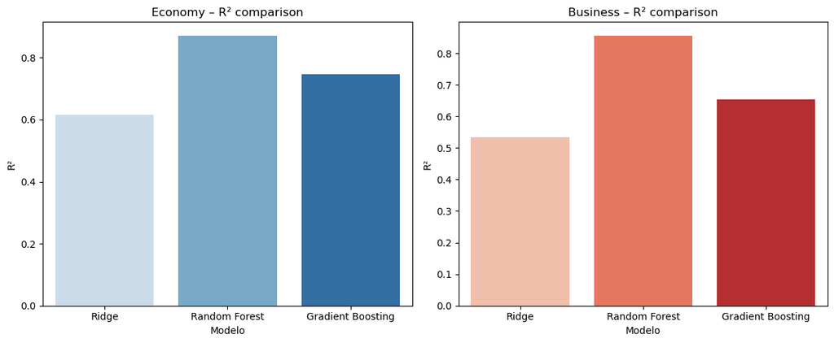

```python
fig, axes = plt.subplots(1, 2, figsize=(12, 5))

sns.barplot(x='Modelo', y='R²', hue='Modelo', data=resultados_econ,
            palette='Blues', legend=False, ax=axes[0])
axes[0].set_title('Economy – R² comparison')

sns.barplot(x='Modelo', y='R²', hue='Modelo', data=resultados_bus,
            palette='Reds', legend=False, ax=axes[1])
axes[1].set_title('Business – R² comparison')

plt.tight_layout()
plt.show()
```

### Observation: visual comparison of R²

The following chart compares the performance of the three models across both segments (*Economy* and *Business*), using the coefficient of determination **R²** as the primary metric.

#### Conclusion

The visual comparison reinforces the numerical results:

- **Random Forest** is the most robust and generalizable model for both *Economy* and *Business*, achieving an optimal balance between accuracy and stability.
- This positions it as **the best candidate for deployment in real-world price prediction environments**, where interpretability can be balanced with high predictive power.

### Overall modeling conclusion

The results confirm that the **Random Forest Regressor** delivers the best overall performance across both segments.  
Its ability to capture **non-linear relationships** and handle **complex feature interactions** allows it to significantly outperform linear models and more configuration-sensitive ensembles.

Consequently, **Random Forest is established as the recommended baseline model** for future project iterations, due to both its accuracy and its robustness to data variability.

## 6. Results

### 6.1 Overall Summary

The predictive analysis enabled the construction of models capable of **estimating flight prices** with good accuracy, clearly differentiating between the *Economy* and *Business* segments.  
The **Random Forest Regressor** showed the best performance in both cases, achieving an **R² above 0.85**, which indicates excellent explanatory power.

| Segment | MAE (Mean Absolute Error) | RMSE (Root Mean Squared Error) | R² |
| --- | --- | --- | --- |
| Economy | 586 | 1110 | 0.87 |
| Business | 2550 | 4783 | 0.86 |

### 6.2 Interpretation of Results

- In the **Economy** segment, the model predicts prices with an **average error below 600 monetary units**, representing high accuracy given the variability of the airline market.
- In **Business**, although the absolute error is higher (due to higher and more dispersed prices), the overall model fit remains strong, with a similar proportion of explained variance.

These results suggest that **temporal variables (month, day, weekday)**, together with **airline, origin city, destination, and number of stops**, are key factors in explaining flight price variability.

### 6.3 Business Implications

- Airlines or travel agencies could **anticipate price fluctuations** based on seasonality, route, and service type, optimizing their pricing strategies.
- Customers could benefit from **price alert systems or recommendation engines**, driven by predictions tailored to their routes and search behavior.
- From an operational perspective, this type of model can be integrated into revenue management platforms to **improve dynamic pricing planning**.

### 6.4 Next Steps

To further strengthen model accuracy and scalability, the following actions are recommended:

- Experiment with **hyperparameter optimization techniques** (e.g., GridSearchCV, Optuna).
- Incorporate additional features (e.g., aircraft type, actual flight duration, holidays).
- Evaluate more advanced models such as **XGBoost or LightGBM**, which may provide marginal performance improvements.

### General Conclusion

This study demonstrates that, with proper feature engineering and a well-configured ensemble model, it is possible to **reliably predict commercial flight prices**.  
These results lay the groundwork for **real-world predictive intelligence applications** in the airline industry, supporting both **commercial efficiency** and **customer experience**.

## 7. Conclusions and Next Steps

### 7.2 Key Learnings

This project reinforces the importance of:

- Applying **thorough and consistent data cleaning** prior to modeling.
- **Balancing interpretability and performance** by selecting models that deliver both technical value and business relevance.
- Designing notebooks with a **reproducible and well-documented structure**, facilitating deployment in collaborative environments such as GitHub or Kaggle.

### 7.3 Next Steps

- Implement an **automated hyperparameter tuning phase** to further optimize ensemble models.
- Evaluate the integration of more advanced algorithms such as **XGBoost, LightGBM, or CatBoost**.
- Develop an **interactive dashboard** or **prediction API** to query estimated prices in real time.
- Explore additional data sources (weather, historical demand, special events) to enrich predictive features.

### Final Conclusion

This work demonstrates how **Data Science can deliver tangible value** to the airline industry by transforming large volumes of data into actionable insights.  
The resulting model not only predicts prices accurately but also provides a foundation for **recommendation systems, dynamic pricing strategies, and market analysis tools**, strengthening strategic decision-making in real-world environments.

## 8. Credits and Technologies Used

### 8.1 Authorship

This project was developed as part of a professional portfolio consolidation process in **Data Science applied to predictive analytics and resource management**.  
It combines technical modeling expertise with a strong focus on **result interpretation and real-world business and sustainability applications**.

### 8.2 Main Technologies and Libraries

| Category | Tools |
| --- | --- |
| **Language** | Python 3.11 |
| **Data analysis & manipulation** | `pandas`, `numpy` |
| **Visualization** | `matplotlib`, `seaborn` |
| **Predictive modeling** | `scikit-learn` |
| **Preprocessing & scaling** | `MinMaxScaler`, `OneHotEncoder` |
| **Environment management** | `Anaconda`, `Jupyter Notebook` |
| **Version control** | `Git` & `GitHub` |

### 8.3 Project Structure

The notebook follows a modular and reproducible structure:

1. **Context and analysis objectives**
2. **Data loading and preparation**
3. **EDA (univariate and bivariate exploratory analysis)**
4. **Feature engineering and preprocessing**
5. **Supervised modeling and validation**
6. **Results and interpretation**
7. **Conclusions and next steps**
8. **Credits and technologies used**

### 8.4 Final Reflection

This project represents a **comprehensive applied Data Science implementation**, combining analytical principles with the scientific perspective developed through biology and natural resources engineering.  
Each step—from data cleaning to model validation—reflects a **systematic, transparent, and continuous-learning-oriented approach**.